# Guía clase 06 - Análisis exploratorio de datos

OCE 386 - Introducción al análisis de datos con R

Dr. José A. Gallardo.

Pontificia Universidad Católica de Valparaíso  
jose.gallardo@pucv.cl

14 September 2021

#### **Introducción**

Los análisis exploratorios de datos son procedimientos que usan los estadisticos para visualizar y explorar los datos de un estudio. Esto les permite investigar la calidad y limpiar los datos previo a la realización de las pruebas estadísticas. Un buen análisis exploratorio de datos debe permitir observar la variación y covariación de los datos, así como establecer modelos básicos de relación e interacción entre las variables bajo estudio.

Los análisis son ante todo un proceso no formal en que el investigador debe iterar entre la generación de algunas preguntas iniciales para explorar sus datos y la visualicación, transformación y modelamiento de sus datos, para luego, usar lo aprendido y volver a generar nuevas preguntas hasta alcanzar un nivel de comprención avanzada de sus datos [**Fuente: R for Data Science**](https://r4ds.had.co.nz/exploratory-data-analysis.html).

#### **Objetivos de aprendizaje**

Los objetivos de aprendizaje de esta guía son:

**1**. - Realizar un análisis exploratorio de datos.

**2**. - Realizar gráficas avanzadas con ggplot2.

**3**. - Elaborar un reporte dinámico en formato pdf con **[Rmarkdown](https://rmarkdown.rstudio.com/)**.

#### Librerías

**readxl**: Permite importar datos a partir de archivos con formato **.xls** y **.xlsx**

**ggplot2**: Librería de visualización de datos preferido para realizar graficas con R [ggplot2 book](https://ggplot2-book.org//)).

**psych**: Libería con un comando simple para realizar histogramas y correlaciones de datos en formato de matriz.

#### **Comandos**

A continuación, se presentan algunos comandos que podrían ser usados para resolver los ejercicios de esta guía. Otros, los usará más adelante en el curso y los deberá investigar por su propia cuenta.

**1.-** Visualiza la variación de tus datos de forma avanzada con ggplot2. Si das los primeros pasos en ggplot2 te sugerimos revisar este capítulo del autor de la librería [Getting started](https://ggplot2-book.org/getting-started.html).

La gunción clave de ggplot2 es **ggplot()**

**2.-** Realiza una gráfica para observar la interacción de 2 factores sobre una variable respuesta con esta función de la libraría **stats**: **interaction.plot()**.

**3.-** Investiga el efecto de uno o más factores sobre una variable respuesta con esta función de la librería **graphics**: **plot.design()**.

**4.-** Explora la distribución de frecuencia y correlación de muchas variables continuas con esta función de la librería **psych**: **pairs.panels**.

### **Ejercicio 1.** Elaborar archivo Rmarkdown

Elabore un archivo o file con extensión **.Rmd** y configurelo para exportar el resultado como un documento dinámico **pdf**. Utilice el siguiente ejemplo para completar la información de metadatos: Título: Reporte EDA, nombre del autor: Su nombre.

Luego guarde inmediatamente su *script* como **script_06_nombre_apellido.Rmd**. Al finalizar la actividad deberá exportar y almacenar este script en su carpeta drive de tareas.

### **Ejercicio 2.** Configuración del reporte

En el primer bloque de códigos o **chunk** configure los comandos de la siguiente manera:

**{r setup, include=TRUE, warning=FALSE,message=FALSE}** **knitr::opts_chunk$set(echo = TRUE)**

Cargue las librerías **stats**, **graphics**, **ggplot2**, **psych** y **readxl** usando la función **library()**.

```r
knitr::opts_chunk$set(echo = TRUE)

# Librería stats está instalada por defecto en la base de R
library(stats)

# Librería graphics está instalada por defecto en la base de R
library(graphics)

# Librería para importar datos
library(readxl)

# Librería psych para analisis de datos de matrices
library(psych)

# Librería para gráficas avanzadas
library(ggplot2)
```

### **Ejercicio 3.** Borrar información de la plantilla

Borre los bloques de códigos R que se generan automáticamente con cada archivo .Rmd y reemplacelos por nuevos bloques de códigos con el botón verde **+C** que se encuentra en la parte superior del panel de códigos.

Ejecute cada uno de los siguientes ejercicios en uno o más bloques de códigos diferentes. Sea ordenado y documente su reporte adecuadamente.

### **Ejercicio 4.** Explorar y visualizar variación de los datos con un histograma

```r
datos <- read_excel("robalo.xlsx")
summary(datos)
```

```
##        id           genotipo             weight
##  Min.   :  1.00   Length:100         Min.   : 75.22
##  1st Qu.: 25.75   Class :character   1st Qu.:291.66
##  Median : 50.50   Mode  :character   Median :414.16
##  Mean   : 50.50                      Mean   :456.26
##  3rd Qu.: 75.25                      3rd Qu.:610.46
##  Max.   :100.00                      Max.   :912.11
```

```r
str(datos)
```

```
## tibble [100 × 3] (S3: tbl_df/tbl/data.frame)
##  $ id      : num [1:100] 1 2 3 4 5 6 7 8 9 10 ...
##  $ genotipo: chr [1:100] "AA" "AC" "AA" "AC" ...
##  $ weight  : num [1:100] 252 521 382 660 870 ...
```

**b)** Transforme las variables **id** y **genotipos** a factor usando la función **as.factor()**. Luego, explore nuevamente el set de datos usando la función **summary()**. Finalmente, explore la variable **genotipos** con la función **table()**. Pruebe explorar la variable continua weight con la función **table()** y discuta con sus compañeros porqué esto **no es adecuado**.

```r
datos$id<- as.factor(datos$id)
datos$genotipo<- as.factor(datos$genotipo)
summary(datos)
```

```
##        id     genotipo     weight
##  1      : 1   AA:53    Min.   : 75.22
##  2      : 1   AC:41    1st Qu.:291.66
##  3      : 1   CC: 6    Median :414.16
##  4      : 1            Mean   :456.26
##  5      : 1            3rd Qu.:610.46
##  6      : 1            Max.   :912.11
##  (Other):94
```

```r
table(datos$genotipo)
```

```
##
## AA AC CC
## 53 41  6
```

```r
# Ejecute como prueba pero no incluya en el reporte esta función table(datos$weight)
```

**c)** A partir del set de datos de **genotipos** elabore una gráfica para la variable continua **weight**. Use el comando **ggplot()**, el argumento **aes()** para seleccionar los datos, y la variable respuesta **weight**. Con el simbolo **+** agregue el comando **geom_histogram()** para obtener un histograma.

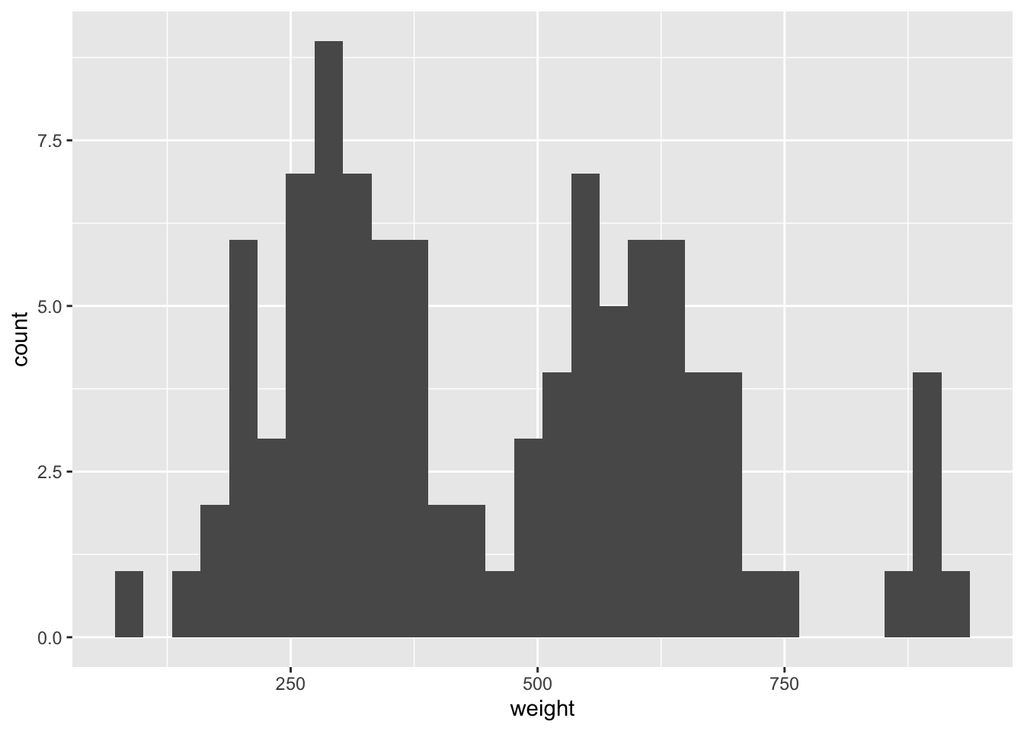

```r
ggplot(datos, aes(x = weight)) +
  geom_histogram()
```

**d)** Para distinguir los diferentes niveles del factor **genotipo** en el histograma, incluya dentro del comando **geom_histogram()** el argumento **aes(color = genotipo)**.

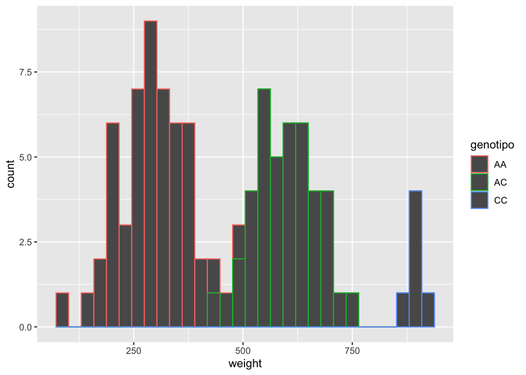

```r
ggplot(datos, aes(x = weight)) +
  geom_histogram(aes(color = genotipo))
```

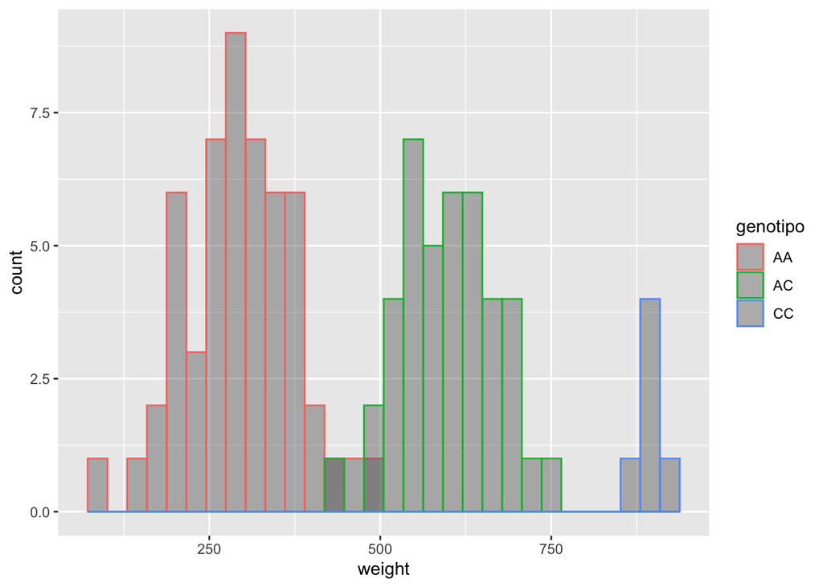

```r
ggplot(datos, aes(x = weight)) +
  geom_histogram(aes(color = genotipo),
  position = "identity", bins = 30, alpha = 0.4)
```

**f)** Grafique la distribución acumulada empírica de la variable **weight** usando el comando **plot(ecdf())** y compare con el histograma anterior. ¿Es posible deducir a partir de la densidad empírica la distribución de frecuencia de los datos?

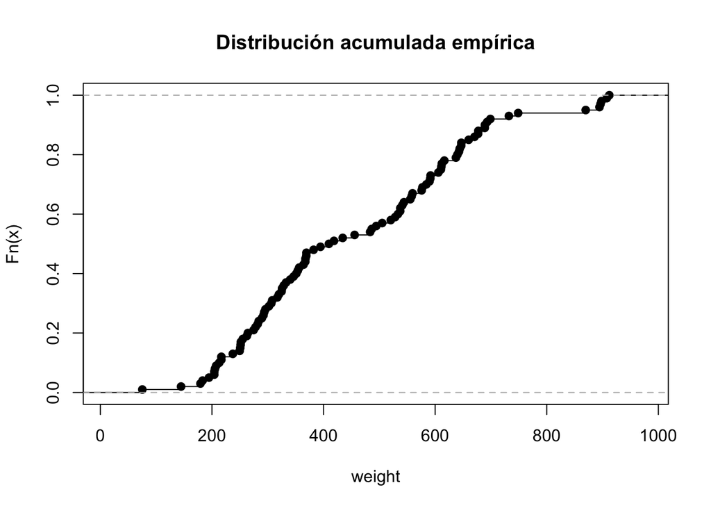

```r
# Distribución acumulada empírica.
plot(ecdf(datos$weight), main="Distribución acumulada empírica", xlab="weight")
```

### **Ejercicio 5.** Explorar y visualizar variación de los datos con un boxplot.

**a)** A partir del set de datos anterior elabore una gráfica de cajas y bigotes para la variable **weight**. Use el comando **ggplot()** y el argumento **aes(x,y)** para seleccionar los datos, donde x será la variable de clasificación **genotipo** e y será la variable respuesta **weight**. Con el simbolo **+** agregue el comando **geom_boxplot()** para obtener un boxplot.

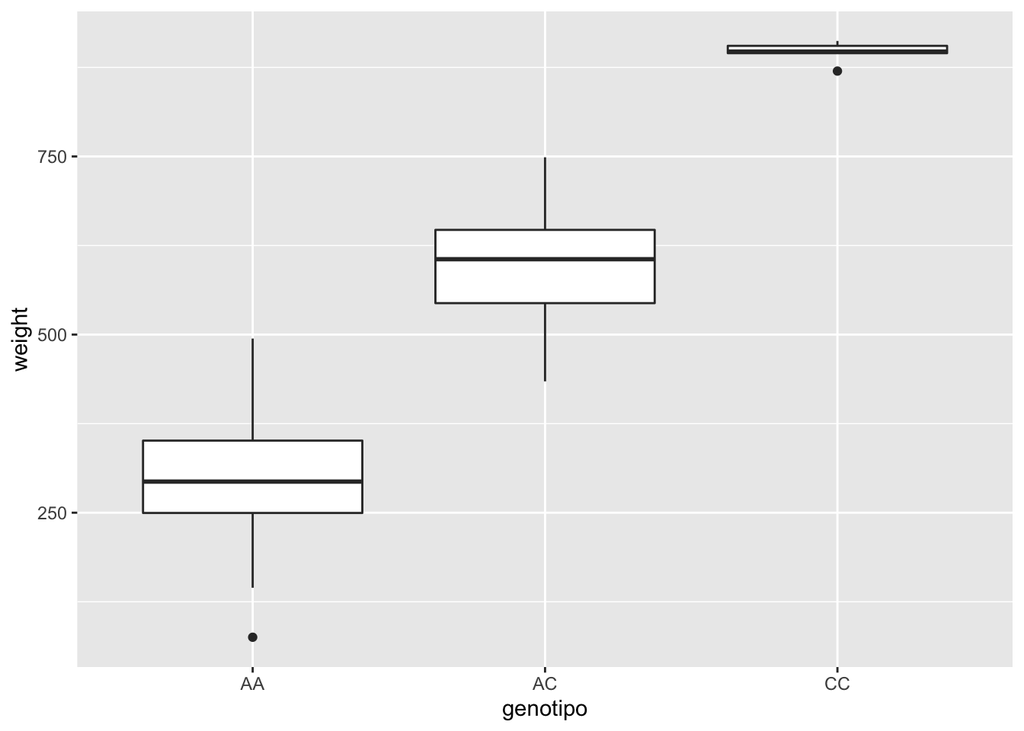

```r
ggplot(datos, aes(x=genotipo, y=weight,)) +
    geom_boxplot()
```

**b)** Para distinguir de mejor forma los diferentes niveles del factor **genotipo** en el boxplot incluya dentro del argumento **aes()** el siguiente argumento **fill = genotipo**.

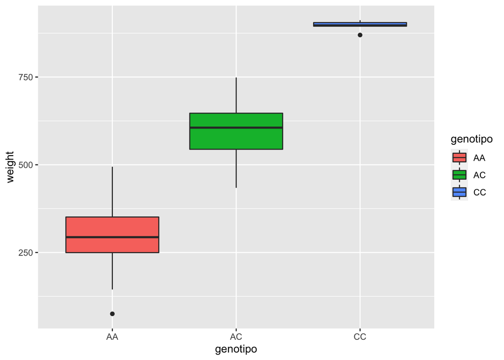

```r
ggplot(datos, aes(x=genotipo, y=weight, fill=genotipo)) +
    geom_boxplot()
```

**c)** Use el comando **labs()** para incluir la etiqueta del eje y “Peso de cosecha (g)”

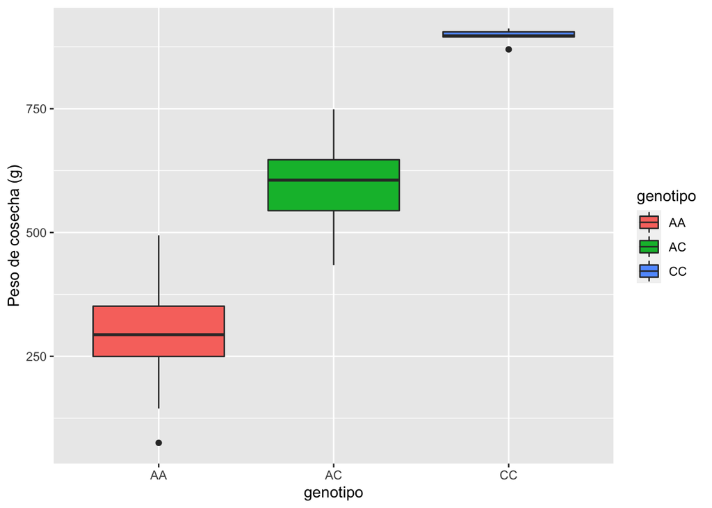

```r
ggplot(datos, aes(x=genotipo, y=weight, fill=genotipo)) +
    geom_boxplot()+
  labs(y="Peso de cosecha (g)")
```

**d)** agregue a al código anterior el comando **geom_jitter()** para visualizar todos los datos de “Peso cuerpo (g)”

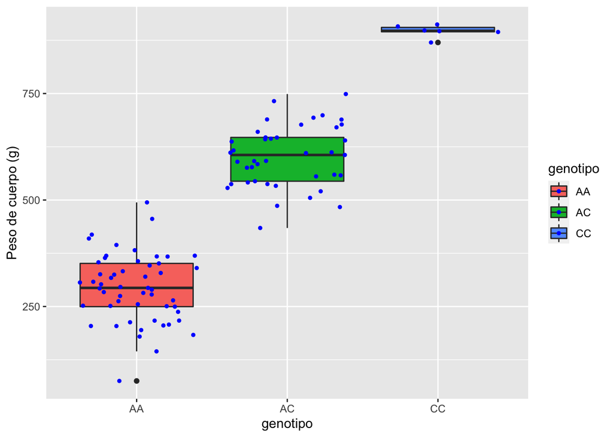

```r
ggplot(datos, aes(x=genotipo, y=weight, fill=genotipo)) +
    geom_boxplot()+
  labs(y="Peso de cuerpo (g)")+
geom_jitter(color="blue", size=1, alpha=2)
```

### **Ejercicio 6.** Explorar y visualizar la interacción de dos factores

**a)** Importe el set de datos **dietas.xslx** usando la función **read_excel()** de la librería **readxl**.

Transforme a factor las columnas **id**, **feed** y **sex** con la función **as.factor()**. Luego, explore el set de datos usando la función **summary()** y explore los factores **feed** y **sex** con la función **table()**. Pruebe explorar la variable **id** con la función **table()** y discuta con sus compañeros porqué **esto no es adecuado**.

```r
dietas <- read_excel("dietas.xlsx")
dietas$id<- as.factor(dietas$id)
dietas$feed<- as.factor(dietas$feed)
dietas$sex<- as.factor(dietas$sex)
summary(dietas)
```

```
##        id     feed        sex         weight
##  1      : 1   d1:12   Hembra:54   Min.   :103.0
##  2      : 1   d2:10   Macho :17   1st Qu.:204.5
##  3      : 1   d3:12               Median :259.0
##  4      : 1   d4:11               Mean   :261.1
##  5      : 1   d5:14               3rd Qu.:325.5
##  6      : 1   d6:12               Max.   :418.0
##  (Other):65
```

```r
table(dietas$feed, dietas$sex)
```

```
##
##      Hembra Macho
##   d1      9     3
##   d2      7     3
##   d3      8     4
##   d4      9     2
##   d5     11     3
##   d6     10     2
```

```r
# Ejecute como prueba pero no incluya en el reporte  table(dietas$feed, dietas$id)
```

**b)** A partir del set de datos de dietas elabore una gráfica de cajas y bigotes para la variable **weight**. Use el comando **ggplot()** y el argumento **aes(x,y,fill)** para seleccionar los datos, el factor **feed**, la variable respuesta **weight** y el 2do factor **sex**. Agregue el comando **geom_boxplot()** para obtener el boxplot.

¿Observa algún patrón claro de interacción entre sex y feed?

¿Cuál de los dos factores tiene mayor influencia en la variable respuesta?

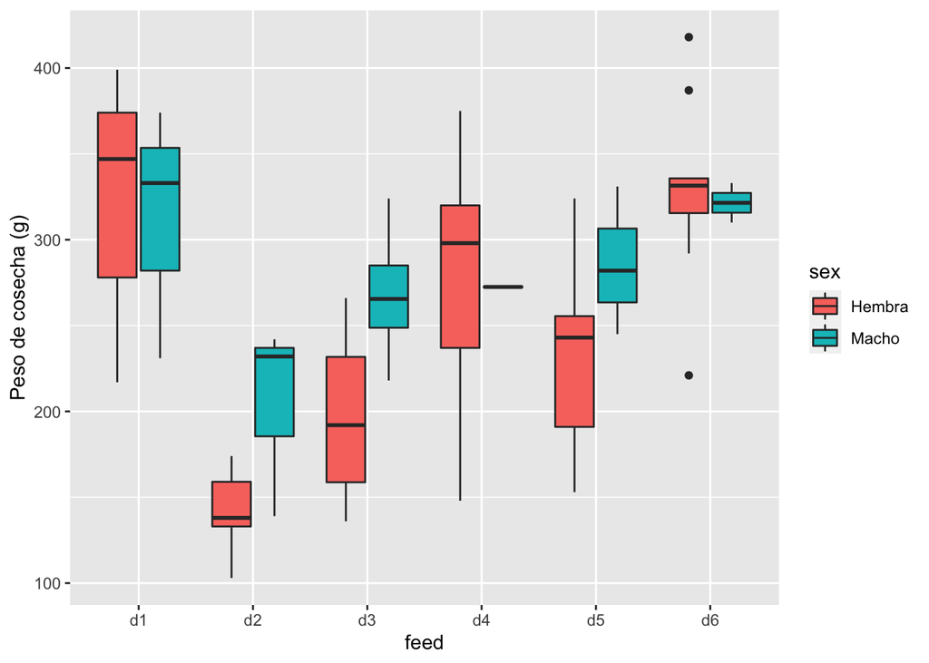

```r
ggplot(dietas, aes(x=feed, y=weight, fill=sex)) +
    geom_boxplot()+
  labs(y="Peso de cosecha (g)")
```

**c)** Realice ahora una gráfica de interacción y una gráfica de tamaño de los efectos de la variable *weight* usando las funcines **interaction.plot()** y **plot.design()**. Incluya *feed* y *sex* como factores.

La forma correcta de escribir el modelo de interacción es el siguiente:

**interaction.plot(factor a, factor b, respuesta, fun=c(mean, median))**

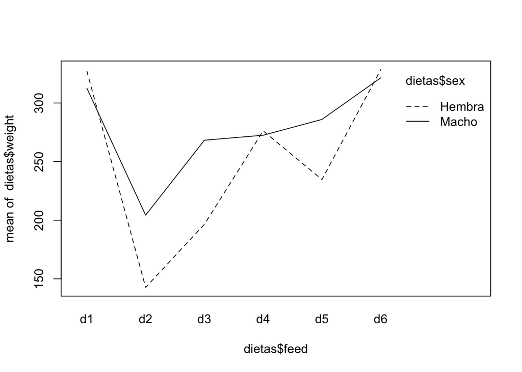

```r
interaction.plot(dietas$feed, dietas$sex, dietas$weight, fun = mean)
```

**d)** Ahora mejore la visualización del gráfico de interacción mediante la inclusión del nombre de los ejes **(xlab="“, ylab”")**, un color para cada tratamiento **col=**, agregar simbolos a cada valor promedio **pch=** e mediante la inclusión tanto de una linea como de un punto con el argumento **type=b**.

Responda: ¿Existe interación entre los factores sex y feed?

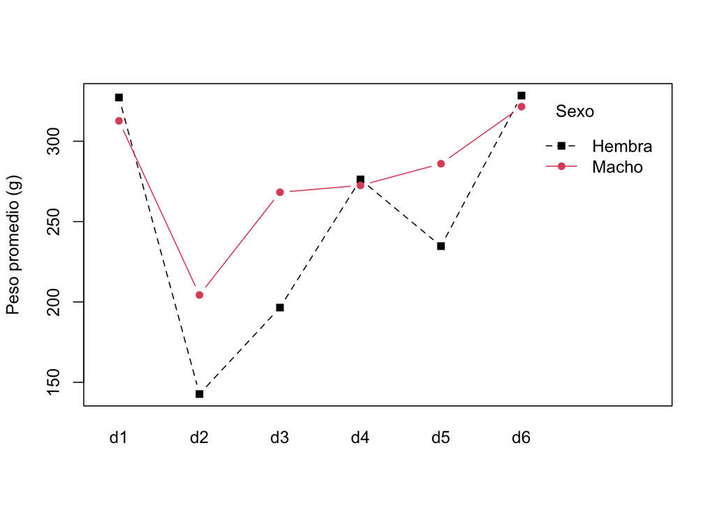

```r
interaction.plot(dietas$feed, dietas$sex, dietas$weight, fun = mean, xlab = "", ylab = "Peso promedio (g)", col=1:2, trace.label="Sexo", pch = c(15, 16), type = "b")
```

**d)** Realice ahora una grafica de tamaño de los efectos de la variable **weight** usando la función **plot.design()**. Incluya **feed** y **sex** como factores.

La forma correcta de escribir el modelo de interacción es el siguiente:

**plot.design(respuesta ~ factor a, factor b)**

el simbolo **~** se lee modelado por o explicado por.

Incluya etiquetas en el eje x e y, de un color a su gráfica con el comando **col=**

Responda: ¿Qué factor tiene una mayor influencia en la variable respuesta weight?

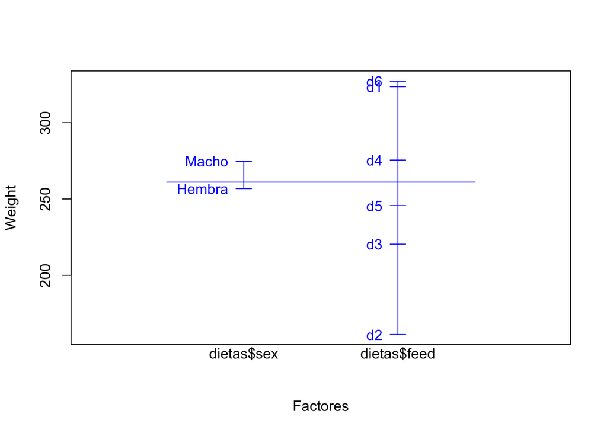

```r
plot.design(dietas$weight~ dietas$sex * dietas$feed, xlab = "Factores", ylab="Weight", col="blue")
```

### **Ejercicio 7.** Explorar y visualizar covariación de variables continuas.

El archivo **“gonada.xlsx”** contiene el registro de peso del cuerpo y peso de la gónada de 100 hembras de róbalo.

**a)** Importe el set de datos **gonada.xslx** usando la función **read_excel()** de la librería **readxl**. Explore el set de datos completo con la función **summary()**.

```r
gonada <- read_excel("gonada.xlsx")
summary(gonada)
```

```
##        id             weight       gonad_weight
##  Min.   :  1.00   Min.   :105.3   Min.   : 1.883
##  1st Qu.: 25.75   1st Qu.:278.6   1st Qu.:30.106
##  Median : 50.50   Median :346.9   Median :38.279
##  Mean   : 50.50   Mean   :355.9   Mean   :38.759
##  3rd Qu.: 75.25   3rd Qu.:411.7   3rd Qu.:45.924
##  Max.   :100.00   Max.   :637.7   Max.   :75.714
```

**b)** Investigue la función **pairs.panels()** de la librería **psych**. Use esta función para obtener histogramas, gráficas de densidad (density = TRUE) y correlación (method = “pearson”) de todas las variables del set de datos.

Responda: ¿Es adecuado incluir en este análisis la variable id?

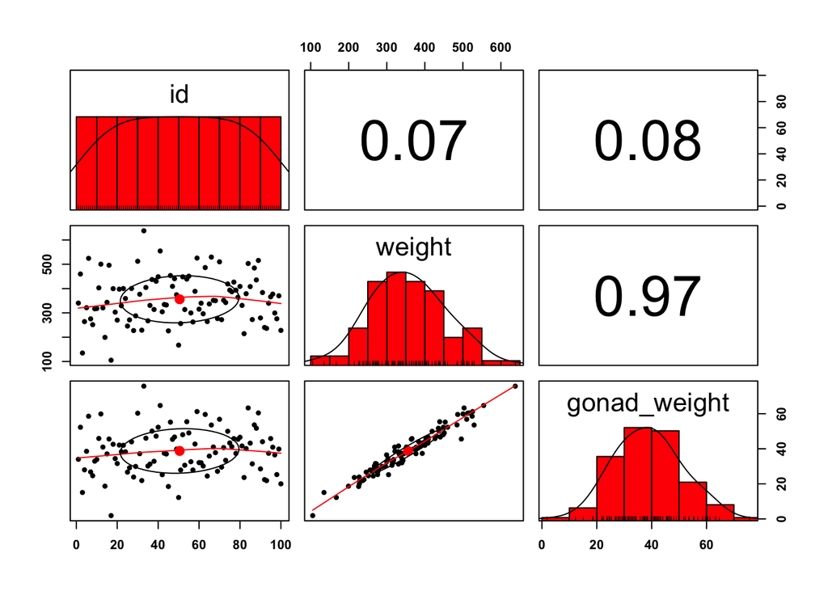

```r
# Gráfica de correlación de variables continuas
pairs.panels(gonada[,], method = "pearson", hist.col = "red",  density = TRUE, font=2)
```

**c)** Elimine la variable **id** del análisis anterior seleccionando las columnas 2 y 3 (gonada[,2:3]) y responda:

¿ Que tipo de distribución tienen las variables **weight** y **gonad_weight**?

¿Están correlacionadas las variables **weight** y **gonad_weight**?

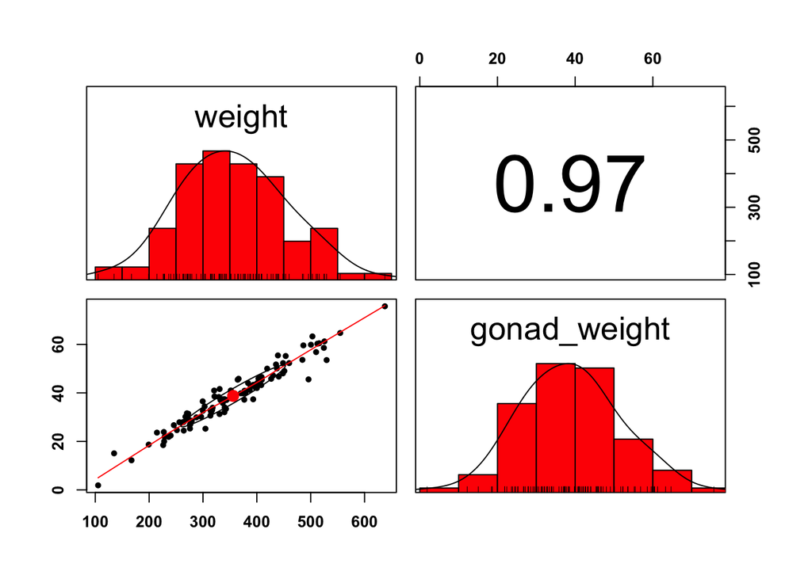

```r
# Gráfica de correlación de variables continuas
pairs.panels(gonada[,2:3], method = "pearson", hist.col = "red",  density = TRUE, font=2)
```